# Analisis de principales variables macroeconomicas de 1990 al 2019 para paises de America Latina

Luis Miguel Meza Ramos

9/4/2021

## Introducción

El presente trabajo tiene como objetivo principal, encontrar relaciones historicas en años pasados de los diferentes paises para si poder prever el futuro. Parte de la premisa: “Si no conocemos la historia estamos condenados a repetirla” y; también busca evaluar historicamente que tanto avanzo el país, ya que comprendiendo el paso es como podremos saber si los diferentes gobiernos de turno fueron eficaces o no en sus medidas tomadas durante su gestión.

## Metodo

Se utilizaran las siguientes técnicas para el analisis.

1. Estadistica descriptiva Cargando la base de datos

```r
library(tidyverse)
library(psych)
desempleo = read.csv("E:/Proyectos R/macroecoomia/desempleo.csv")
desempleo_of = gather(desempleo, periodo, tasa_desempleo, c("X1990":"X2019"))
dim(desempleo)
```

```
## [1] 23 33
```

```r
str(desempleo)
```

```
## 'data.frame':    23 obs. of  33 variables:
##  $ ISO               : chr  "ARG" "ABW" "BHS" "BRB" ...
##  $ Country           : chr  "Argentina" "Aruba" "The Bahamas" "Barbados" ...
##  $ Subject.Descriptor: chr  "Unemployment rate" "Unemployment rate" "Unemployment rate" "Unemployment rate" ...
##  $ X1990             : chr  "7.6" "n/a" "12" "14.945" ...
##  $ X1991             : chr  "6.48" "n/a" "12.3" "17.236" ...
##  $ X1992             : chr  "7.112" "n/a" "14.8" "22.915" ...
##  $ X1993             : chr  "11.606" "n/a" "13.1" "24.41" ...
##  $ X1994             : chr  "13.348" "n/a" "13.292" "21.75" ...
##  $ X1995             : chr  "18.904" "n/a" "10.9" "19.625" ...
##  $ X1996             : chr  "18.76" "n/a" "11.505" "15.75" ...
##  $ X1997             : chr  "16.808" "n/a" "9.779" "14.55" ...
##  $ X1998             : chr  "14.789" "3.25" "7.743" "12.15" ...
##  $ X1999             : chr  "16.061" "4.793" "7.796" "10.35" ...
##  $ X2000             : num  17.13 6.92 7 9.35 11.4 ...
```

[output cut: 19 more lines]

```r
desempleo_of$tasa_desempleo = as.numeric(desempleo_of$tasa_desempleo)
desempleo_num = spread(desempleo_of, periodo, tasa_desempleo)
desempleo_num = na.omit(desempleo_num)
```

A contunuación procedemos a extraer la media de cada país.

```r
rowMeans(desempleo_num[,4:33])
```

```
##         2         3         4         7         8         9        10        12
## 11.557033 11.274733 11.930533 12.506267  7.817467 10.080567  7.079433  6.735900
##        13        14        15        16        17        18        19        20
##  4.055567 13.444167  3.836667  9.281100  9.797467  7.929100  6.118700  7.210467
##        22
##  9.876133
```

2. Analisis de componentes principales (ACP)

```r
KMO(desempleo_num[c(4:13)])
```

```
## Kaiser-Meyer-Olkin factor adequacy
## Call: KMO(r = desempleo_num[c(4:13)])
## Overall MSA =  0.78
## MSA for each item =
## X1990 X1991 X1992 X1993 X1994 X1995 X1996 X1997 X1998 X1999
##  0.86  0.76  0.78  0.75  0.76  0.85  0.85  0.88  0.70  0.62
```

```r
bartlett.test(desempleo_num[c(4:13)])
```

```
##
##  Bartlett test of homogeneity of variances
##
## data:  desempleo_num[c(4:13)]
## Bartlett's K-squared = 5.3419, df = 9, p-value = 0.8035
```

A continuación procedemos a ejecutar el ACP en R.

```r
acp = prcomp(desempleo_num[c(4:13)], scale. = TRUE)
summary(acp)
```

```
## Importance of components:
##                           PC1    PC2    PC3     PC4     PC5    PC6     PC7
## Standard deviation     2.8430 1.0700 0.6419 0.47706 0.21491 0.1923 0.16611
## Proportion of Variance 0.8083 0.1145 0.0412 0.02276 0.00462 0.0037 0.00276
## Cumulative Proportion  0.8083 0.9227 0.9639 0.98669 0.99130 0.9950 0.99776
##                            PC8     PC9    PC10
## Standard deviation     0.11049 0.08246 0.05809
## Proportion of Variance 0.00122 0.00068 0.00034
## Cumulative Proportion  0.99898 0.99966 1.00000
```

Determinación del número de componentes principales a utilizar. Del gráfico se observa que utilizaremos 2 componentes principales.

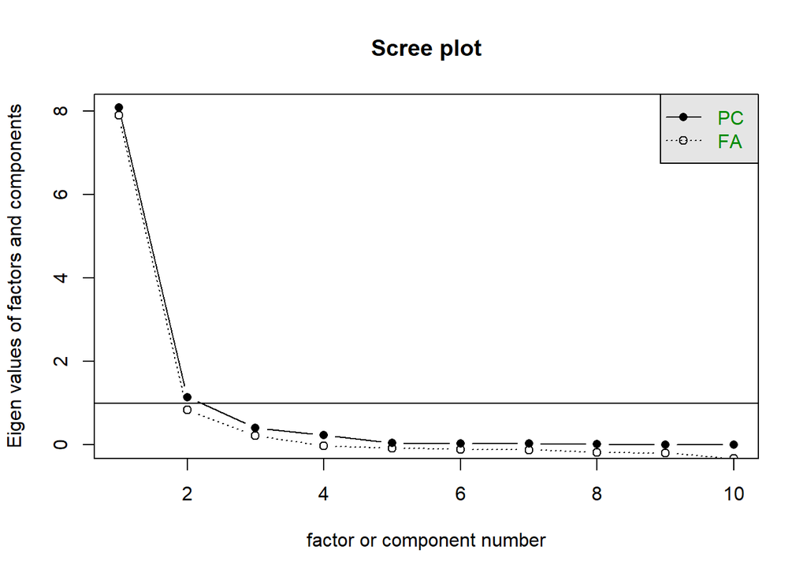

```r
scree(desempleo_num[c(4:13)])
```

Procedemos determinar la correlacion entre los valores iniciales y la scores

```r
options(digits = 4)
cor(desempleo_num[c(4:13)], acp$x[,1:2])
```

```
##          PC1      PC2
## X1990 0.8963  0.24728
## X1991 0.9020  0.29293
## X1992 0.8967  0.38380
## X1993 0.9211  0.28676
## X1994 0.9420  0.22276
## X1995 0.9395 -0.04678
## X1996 0.9347 -0.23198
## X1997 0.9549 -0.24426
## X1998 0.8957 -0.40539
## X1999 0.6747 -0.66233
```

Procemos a realizar un ranking de paises

```r
eigen_val = eigen(cor(desempleo_num[c(4:13)]))
eigen_val
```

```
## eigen() decomposition
## $values
##  [1] 8.082451 1.144798 0.412015 0.227586 0.046185 0.036990 0.027592 0.012208
##  [9] 0.006800 0.003375
##
## $vectors
##          [,1]     [,2]    [,3]    [,4]    [,5]     [,6]     [,7]     [,8]
##  [1,] -0.3153 -0.23111  0.4444 -0.4107  0.4112 -0.41551  0.01852  0.32819
##  [2,] -0.3173 -0.27378  0.4375 -0.1527 -0.1240  0.61739  0.06672 -0.25652
##  [3,] -0.3154 -0.35871  0.1457  0.3748 -0.2959 -0.13049  0.04668 -0.29413
##  [4,] -0.3240 -0.26802 -0.1903  0.4501 -0.1966 -0.23089 -0.26899  0.34138
##  [5,] -0.3314 -0.20820 -0.3218  0.1663  0.4175  0.11428  0.33991  0.07646
##  [6,] -0.3305  0.04372 -0.4711 -0.2001  0.2335  0.43112 -0.34957  0.10455
##  [7,] -0.3288  0.21682 -0.2641 -0.3135 -0.4507 -0.11445  0.64018  0.11073
##  [8,] -0.3359  0.22829 -0.1476 -0.1501  0.1394 -0.38780 -0.23363 -0.71311
##  [9,] -0.3151  0.37888  0.1924 -0.1340 -0.3804  0.04096 -0.42008  0.28830
## [10,] -0.2373  0.61902  0.3156  0.5084  0.3053  0.10836  0.20506  0.05253
##          [,9]    [,10]
##  [1,] -0.1749 -0.02633
##  [2,]  0.2178 -0.30890
##  [3,] -0.4670  0.44584
##  [4,]  0.1749 -0.52245
##  [5,]  0.4927  0.40505
##  [6,] -0.5031 -0.01679
##  [7,] -0.1170 -0.15749
##  [8,]  0.1898 -0.14762
##  [9,]  0.3084  0.44847
## [10,] -0.1803 -0.14177
```

```r
ranking = (8.082451348*acp$x[,1] + 1.144797940*acp$x[,2])/(8.082451348+1.144797940)

promedio_1990_1999 = rowMeans(desempleo_num[,4:13])
desempleo_num = data.frame(desempleo_num,ranking, promedio_1990_1999)
df_ranking = data.frame(desempleo_num$Country, desempleo_num$ranking, promedio_1990_1999)
df_ranking
```

```
##    desempleo_num.Country desempleo_num.ranking promedio_1990_1999
## 2              Argentina               1.74165             13.147
## 3            The Bahamas               1.00066             11.322
## 4                 Belize               1.67960             12.610
## 7               Barbados               4.51290             17.368
## 8                  Chile              -1.46656              7.318
## 9               Colombia              -1.55856              7.305
## 10            Costa Rica              -2.69547              5.126
## 12               Ecuador              -0.95137              8.313
## 13              Honduras              -3.49997              3.675
## 14               Jamaica               3.50556             15.840
## 15                Mexico              -3.53410              3.646
## 16             Nicaragua               2.99687             14.793
## 17                Panama               2.44918             13.747
## 18                  Peru              -0.97441              8.150
## 19              Paraguay              -2.43593              5.560
## 20           El Salvador              -0.79900              8.260
## 22               Uruguay               0.02894              9.898
```

```r
arrange(df_ranking, desempleo_num.ranking)
```

```
##    desempleo_num.Country desempleo_num.ranking promedio_1990_1999
## 15                Mexico              -3.53410              3.646
## 13              Honduras              -3.49997              3.675
## 10            Costa Rica              -2.69547              5.126
## 19              Paraguay              -2.43593              5.560
## 9               Colombia              -1.55856              7.305
## 8                  Chile              -1.46656              7.318
## 18                  Peru              -0.97441              8.150
## 12               Ecuador              -0.95137              8.313
## 20           El Salvador              -0.79900              8.260
## 22               Uruguay               0.02894              9.898
## 3            The Bahamas               1.00066             11.322
## 4                 Belize               1.67960             12.610
## 2              Argentina               1.74165             13.147
## 17                Panama               2.44918             13.747
## 16             Nicaragua               2.99687             14.793
## 14               Jamaica               3.50556             15.840
## 7               Barbados               4.51290             17.368
```

Se procede a realizar un gráfico biplot. Se observa en el gráfico bliplot que para los años 1990 hasta 1994, su ubican en el 1er cuadrante del plano cartesiano. Y, para los años 1995 a 1999, se ubican en el 4to cuadrante del plano cartesiano. Lo cual sugiere que se dio un punto de quiebre en el desempleo a finales de 1994.

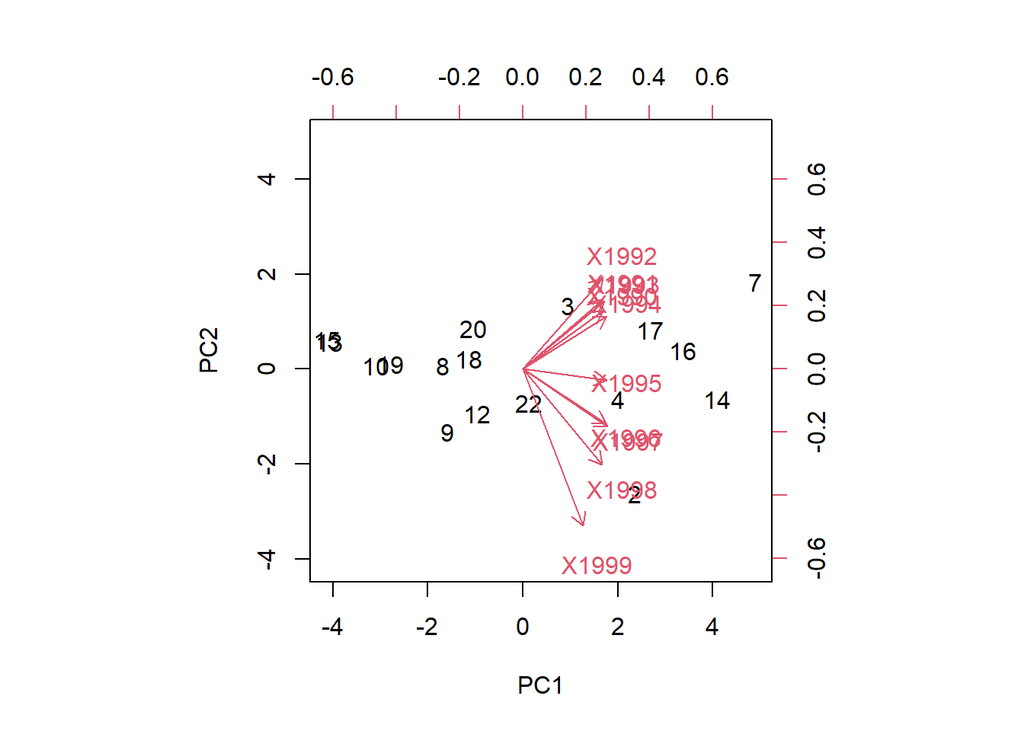

```r
biplot(acp, scale = 0)
```

gráfico de los dos primeros componentes por pais

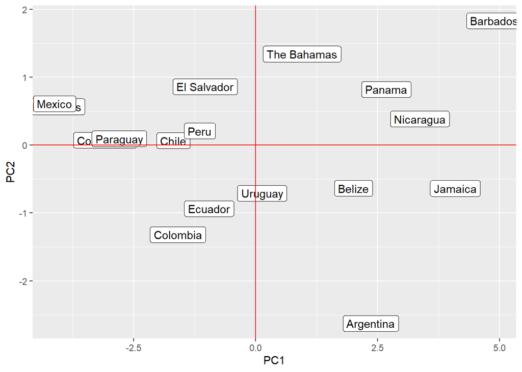

```r
scores = cbind(desempleo_num, acp$x)
ggplot(scores, aes(x = PC1, y = PC2, label = Country))+
  geom_label()+
  geom_vline(xintercept = 0, color = "red")+
  geom_hline(yintercept = 0, color = "red")
```

gráfico de los dos primeros componentes por ranking

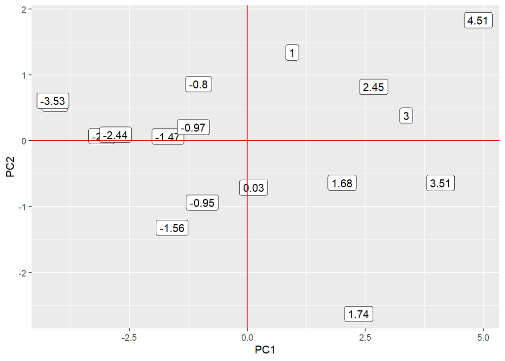

```r
ggplot(scores, aes(x = PC1, y = PC2, label = round(ranking,2)))+
  geom_label()+
  geom_vline(xintercept = 0, color = "red")+
  geom_hline(yintercept = 0, color = "red")
```

## Referencias

International Labour Organization. (s. f.). International Labour Organization. https://ilostat.ilo.org. Recuperado 9 de abril de 2021, de https://ilostat.ilo.org/data/